# Exploratory Data Analysis Of Instacart Online Store

Mayank as Shubham Karan

2023-01-26

## Data-driven decision-making

Data-driven decision-making (DDDM) is defined as using facts, metrics, and data to guide strategic business decisions that align with your goals, objectives, and initiatives. Various of Data-driven decision-making process has been defined by Industry experts. There is no universal DDDM process but most of the DDDM follows the almost same process. The method used in this project is Ask - Prepare - Process - Analyze - Share - Act ( APPASA )

## ASK

### Introduction

The online Retail is a UK based seller of occasional gifts which operates in Various country across the globe, many customers of company are wholesellers. This case study has been done to answer following questions

1. Which are Top 5 country based on Order volume ?
2. Which are Top products in various country ?
3. Which products generate most sales in Top country ?
4. What time products are sold most in across Country ?
5. Which day products are sold most in across Country ?
6. Which month products are sold most in across Country ?

And to help making a data driven decision making using (APPASA) in managing inventory, generating more revenue and as well as in tracking various KPI.

### Stakeholder

Primary Stakeholder : Yeah ! thats me as I as I invested My time in doing EDA

Secondary Stakeholder : Thats you as you are reading my portfolio project

## Prepare

### Data Set & Metadata

This data set includes

*InvoiceNo:* Invoice number. Nominal

*StockCode:* Product (item) code. Nominal

*Description:* Product (item) name. Nominal

*Quantity:* The quantities of each product (item) per transaction. Numeric

*InvoiceDate:* Invoice Date and time. Numeric, the day and time when each transaction was generated.

*UnitPrice:* Unit price. Numeric

*CustomerID:* Customer number. Nominal

*Country:* Country name. Nominal

### ROCCC analysis

1. Reliable
2. Original
3. Comprehensive
4. Current
5. Cited

Data set checks **yes** in all criteria of ROCCC analysis.

### Installing Required Packages

The packages used in this data analysis are : tidyverse, dplyr, skimr, janitor, lubridate, readxl

and installed using : install.packages(“package_name”)

### Loading Required Packages

```r
library(tidyverse)
library(here)
library(dplyr)
```

```r
library(skimr)
```

```r
library(janitor)
library(lubridate)
```

```r
library(readr)
```

```r
library(readxl)
```

## PROCESS

### Uploading data Into Workbench

```r
Online_Retail_1_ <- read_excel("~/Data/Instacart/Online Retail (1).xlsx")
```

```r
online_retail_II <- read_excel("~/Data/Instacart/online_retail_II.xlsx")
```

```r
#Checking Column Names and looking for Inconsistency
str(Online_Retail_1_)
```

```
## tibble [541,909 × 8] (S3: tbl_df/tbl/data.frame)
##  $ InvoiceNo  : chr [1:541909] "536365" "536365" "536365" "536365" ...
##  $ StockCode  : chr [1:541909] "85123A" "71053" "84406B" "84029G" ...
##  $ Description: chr [1:541909] "WHITE HANGING HEART T-LIGHT HOLDER" "WHITE METAL LANTERN" "CREAM CUPID HEARTS COAT HANGER" "KNITTED UNION FLAG HOT WATER BOTTLE" ...
##  $ Quantity   : num [1:541909] 6 6 8 6 6 2 6 6 6 32 ...
##  $ InvoiceDate: POSIXct[1:541909], format: "2010-12-01 08:26:00" "2010-12-01 08:26:00" ...
##  $ UnitPrice  : num [1:541909] 2.55 3.39 2.75 3.39 3.39 7.65 4.25 1.85 1.85 1.69 ...
##  $ CustomerID : num [1:541909] 17850 17850 17850 17850 17850 ...
##  $ Country    : chr [1:541909] "United Kingdom" "United Kingdom" "United Kingdom" "United Kingdom" ...
```

```r
#Checking Column Names and looking for Inconsistency
str(online_retail_II)
```

```
## tibble [525,461 × 8] (S3: tbl_df/tbl/data.frame)
##  $ Invoice    : chr [1:525461] "489434" "489434" "489434" "489434" ...
##  $ StockCode  : chr [1:525461] "85048" "79323P" "79323W" "22041" ...
##  $ Description: chr [1:525461] "15CM CHRISTMAS GLASS BALL 20 LIGHTS" "PINK CHERRY LIGHTS" "WHITE CHERRY LIGHTS" "RECORD FRAME 7\" SINGLE SIZE" ...
##  $ Quantity   : num [1:525461] 12 12 12 48 24 24 24 10 12 12 ...
##  $ InvoiceDate: POSIXct[1:525461], format: "2009-12-01 07:45:00" "2009-12-01 07:45:00" ...
##  $ Price      : num [1:525461] 6.95 6.75 6.75 2.1 1.25 1.65 1.25 5.95 2.55 3.75 ...
##  $ Customer ID: num [1:525461] 13085 13085 13085 13085 13085 ...
##  $ Country    : chr [1:525461] "United Kingdom" "United Kingdom" "United Kingdom" "United Kingdom" ...
```

Inconsistency found in column names between Online_Retail_1_ And online_retail_II

```r
#Changing Column names in Both Online_Retail_1_ And online_retail_II & Converting into New Data Frame
Online_Retail_1_v1 <- Online_Retail_1_ %>% rename(invoice_number = InvoiceNo, stock_code = StockCode, description = Description, quantity = Quantity, invoice_date = InvoiceDate, unit_price = UnitPrice, customer_id = CustomerID, country = Country)
```

```r
online_retail_II_v1 <- online_retail_II %>% rename(invoice_number = Invoice, stock_code = StockCode, description = Description, quantity = Quantity, invoice_date = InvoiceDate, unit_price = Price, customer_id = `Customer ID`, country = Country)
```

```r
#Checking Column New data Frame and looking for Incosistancy
str(Online_Retail_1_v1)
```

```
## tibble [541,909 × 8] (S3: tbl_df/tbl/data.frame)
##  $ invoice_number: chr [1:541909] "536365" "536365" "536365" "536365" ...
##  $ stock_code    : chr [1:541909] "85123A" "71053" "84406B" "84029G" ...
##  $ description   : chr [1:541909] "WHITE HANGING HEART T-LIGHT HOLDER" "WHITE METAL LANTERN" "CREAM CUPID HEARTS COAT HANGER" "KNITTED UNION FLAG HOT WATER BOTTLE" ...
##  $ quantity      : num [1:541909] 6 6 8 6 6 2 6 6 6 32 ...
##  $ invoice_date  : POSIXct[1:541909], format: "2010-12-01 08:26:00" "2010-12-01 08:26:00" ...
##  $ unit_price    : num [1:541909] 2.55 3.39 2.75 3.39 3.39 7.65 4.25 1.85 1.85 1.69 ...
##  $ customer_id   : num [1:541909] 17850 17850 17850 17850 17850 ...
##  $ country       : chr [1:541909] "United Kingdom" "United Kingdom" "United Kingdom" "United Kingdom" ...
```

```r
#Checking Column New data Frame and looking for Incosistancy
str(online_retail_II_v1)
```

```
## tibble [525,461 × 8] (S3: tbl_df/tbl/data.frame)
##  $ invoice_number: chr [1:525461] "489434" "489434" "489434" "489434" ...
##  $ stock_code    : chr [1:525461] "85048" "79323P" "79323W" "22041" ...
##  $ description   : chr [1:525461] "15CM CHRISTMAS GLASS BALL 20 LIGHTS" "PINK CHERRY LIGHTS" "WHITE CHERRY LIGHTS" "RECORD FRAME 7\" SINGLE SIZE" ...
##  $ quantity      : num [1:525461] 12 12 12 48 24 24 24 10 12 12 ...
##  $ invoice_date  : POSIXct[1:525461], format: "2009-12-01 07:45:00" "2009-12-01 07:45:00" ...
##  $ unit_price    : num [1:525461] 6.95 6.75 6.75 2.1 1.25 1.65 1.25 5.95 2.55 3.75 ...
##  $ customer_id   : num [1:525461] 13085 13085 13085 13085 13085 ...
##  $ country       : chr [1:525461] "United Kingdom" "United Kingdom" "United Kingdom" "United Kingdom" ...
```

### Making a new Data Frame by Combining Rows of Online_Retail_1_v1 & online_retail_II_v1

```r
online_shop <- bind_rows(Online_Retail_1_v1, online_retail_II_v1)
```

### Inspecting New Data Frame online_shop

```r
str(online_shop)
```

```
## tibble [1,067,370 × 8] (S3: tbl_df/tbl/data.frame)
##  $ invoice_number: chr [1:1067370] "536365" "536365" "536365" "536365" ...
##  $ stock_code    : chr [1:1067370] "85123A" "71053" "84406B" "84029G" ...
##  $ description   : chr [1:1067370] "WHITE HANGING HEART T-LIGHT HOLDER" "WHITE METAL LANTERN" "CREAM CUPID HEARTS COAT HANGER" "KNITTED UNION FLAG HOT WATER BOTTLE" ...
##  $ quantity      : num [1:1067370] 6 6 8 6 6 2 6 6 6 32 ...
##  $ invoice_date  : POSIXct[1:1067370], format: "2010-12-01 08:26:00" "2010-12-01 08:26:00" ...
##  $ unit_price    : num [1:1067370] 2.55 3.39 2.75 3.39 3.39 7.65 4.25 1.85 1.85 1.69 ...
##  $ customer_id   : num [1:1067370] 17850 17850 17850 17850 17850 ...
##  $ country       : chr [1:1067370] "United Kingdom" "United Kingdom" "United Kingdom" "United Kingdom" ...
```

```r
#Checking Column names
colnames(online_shop)
```

```
## [1] "invoice_number" "stock_code"     "description"    "quantity"
## [5] "invoice_date"   "unit_price"     "customer_id"    "country"
```

```r
#Number Of Row
nrow(online_shop)
```

```
## [1] 1067370
```

```r
dim(online_shop)
```

```
## [1] 1067370       8
```

```r
#Checking First 6 Rows of Data
head(online_shop)
```

```
## # A tibble: 6 × 8
##   invoice_number stock_code description  quantity invoice_date        unit_price
##   <chr>          <chr>      <chr>           <dbl> <dttm>                   <dbl>
## 1 536365         85123A     WHITE HANGI…        6 2010-12-01 08:26:00       2.55
## 2 536365         71053      WHITE METAL…        6 2010-12-01 08:26:00       3.39
## 3 536365         84406B     CREAM CUPID…        8 2010-12-01 08:26:00       2.75
## 4 536365         84029G     KNITTED UNI…        6 2010-12-01 08:26:00       3.39
## 5 536365         84029E     RED WOOLLY …        6 2010-12-01 08:26:00       3.39
## 6 536365         22752      SET 7 BABUS…        2 2010-12-01 08:26:00       7.65
## # ℹ 2 more variables: customer_id <dbl>, country <chr>
```

```r
#Checking Summary Of Data Frame
summary(online_shop)
```

```
##  invoice_number      stock_code        description           quantity
##  Length:1067370     Length:1067370     Length:1067370     Min.   :-80995.00
##  Class :character   Class :character   Class :character   1st Qu.:     1.00
##  Mode  :character   Mode  :character   Mode  :character   Median :     3.00
##                                                           Mean   :     9.94
##                                                           3rd Qu.:    10.00
##                                                           Max.   : 80995.00
##
##   invoice_date                      unit_price         customer_id
##  Min.   :2009-12-01 07:45:00.00   Min.   :-53594.36   Min.   :12346
##  1st Qu.:2010-07-09 09:46:00.00   1st Qu.:     1.25   1st Qu.:13975
##  Median :2010-12-07 15:28:00.00   Median :     2.10   Median :15255
##  Mean   :2011-01-02 21:13:27.81   Mean   :     4.65   Mean   :15325
##  3rd Qu.:2011-07-22 10:23:00.00   3rd Qu.:     4.15   3rd Qu.:16797
##  Max.   :2011-12-09 12:50:00.00   Max.   : 38970.00   Max.   :18287
##                                                       NA's   :243007
##    country
##  Length:1067370
##  Class :character
##  Mode  :character
##
##
##
##
```

```r
#Viewing Some Data
glimpse(online_shop)
```

```
## Rows: 1,067,370
## Columns: 8
## $ invoice_number <chr> "536365", "536365", "536365", "536365", "536365", "5363…
## $ stock_code     <chr> "85123A", "71053", "84406B", "84029G", "84029E", "22752…
## $ description    <chr> "WHITE HANGING HEART T-LIGHT HOLDER", "WHITE METAL LANT…
## $ quantity       <dbl> 6, 6, 8, 6, 6, 2, 6, 6, 6, 32, 6, 6, 8, 6, 6, 3, 2, 3, …
## $ invoice_date   <dttm> 2010-12-01 08:26:00, 2010-12-01 08:26:00, 2010-12-01 0…
## $ unit_price     <dbl> 2.55, 3.39, 2.75, 3.39, 3.39, 7.65, 4.25, 1.85, 1.85, 1…
## $ customer_id    <dbl> 17850, 17850, 17850, 17850, 17850, 17850, 17850, 17850,…
## $ country        <chr> "United Kingdom", "United Kingdom", "United Kingdom", "…
```

### Filtering, Cleaning & Adding new Columns

```r
#Checking Null values
colSums(is.na(online_shop))
```

```
## invoice_number     stock_code    description       quantity   invoice_date
##              0              0           4382              0              0
##     unit_price    customer_id        country
##              0         243007              0
```

```r
#Droping Null values
online_shop <- drop_na(online_shop)
```

```r
#Checking Null values again
online_shop %>% is.na %>% colSums
```

```
## invoice_number     stock_code    description       quantity   invoice_date
##              0              0              0              0              0
##     unit_price    customer_id        country
##              0              0              0
```

```r
#Converting country & description to Factor
online_shop <- online_shop %>% mutate(description = as.factor(description), country = as.factor(country))
```

```r
#Saving new Column date_time
online_shop$date_time <- strptime(online_shop$invoice_date, "%Y-%m-%d %H:%M:%S")
```

```r
#Saving new Column month
online_shop$month <- format(as.Date(online_shop$date_time), "%m")
```

```r
#Saving new Column  month_str
online_shop$month_str <- format(as.Date(online_shop$date_time), "%B")
```

```r
#Saving new Column date
online_shop$date <- format(as.Date(online_shop$date_time), "%d")
```

```r
#Saving new Column time_hms
online_shop$time_hms <- format(online_shop$date_time, "%H:%M:%S")
```

```r
#Saving new Column time_hm
online_shop$time_hm <- format(online_shop$date_time, "%H:%M")
```

```r
#Saving new Column time_h
online_shop$time_h <- format(online_shop$date_time, "%H")
```

```r
#Saving new Column Day
online_shop$day <- format(as.Date(online_shop$invoice_date), "%A")
```

```r
#Saving new Column total_sales
online_shop$total_sales <- online_shop$quantity * online_shop$unit_price
```

```r
#Viewing Some Data
glimpse(online_shop)
```

```
## Rows: 824,363
## Columns: 17
## $ invoice_number <chr> "536365", "536365", "536365", "536365", "536365", "5363…
## $ stock_code     <chr> "85123A", "71053", "84406B", "84029G", "84029E", "22752…
## $ description    <fct> "WHITE HANGING HEART T-LIGHT HOLDER", "WHITE METAL LANT…
## $ quantity       <dbl> 6, 6, 8, 6, 6, 2, 6, 6, 6, 32, 6, 6, 8, 6, 6, 3, 2, 3, …
## $ invoice_date   <dttm> 2010-12-01 08:26:00, 2010-12-01 08:26:00, 2010-12-01 0…
## $ unit_price     <dbl> 2.55, 3.39, 2.75, 3.39, 3.39, 7.65, 4.25, 1.85, 1.85, 1…
## $ customer_id    <dbl> 17850, 17850, 17850, 17850, 17850, 17850, 17850, 17850,…
## $ country        <fct> United Kingdom, United Kingdom, United Kingdom, United …
## $ date_time      <dttm> 2010-12-01 08:26:00, 2010-12-01 08:26:00, 2010-12-01 0…
## $ month          <chr> "12", "12", "12", "12", "12", "12", "12", "12", "12", "…
## $ month_str      <chr> "December", "December", "December", "December", "Decemb…
## $ date           <chr> "01", "01", "01", "01", "01", "01", "01", "01", "01", "…
## $ time_hms       <chr> "08:26:00", "08:26:00", "08:26:00", "08:26:00", "08:26:…
## $ time_hm        <chr> "08:26", "08:26", "08:26", "08:26", "08:26", "08:26", "…
## $ time_h         <chr> "08", "08", "08", "08", "08", "08", "08", "08", "08", "…
## $ day            <chr> "Wednesday", "Wednesday", "Wednesday", "Wednesday", "We…
## $ total_sales    <dbl> 15.30, 20.34, 22.00, 20.34, 20.34, 15.30, 25.50, 11.10,…
```

## ANALYZE

### Calculating Number Of Order

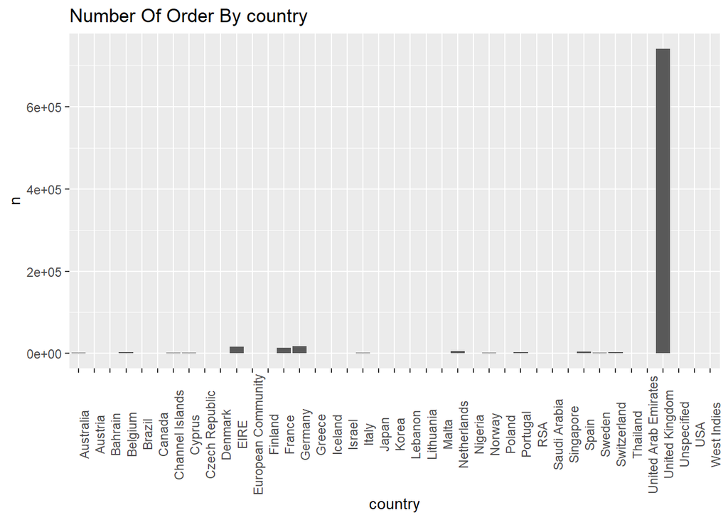

```r
#Number Of Order by Country
Number_Of_order <- online_shop %>% count(country) %>% ggplot() + geom_col(aes(x = country, y = n))+ theme(axis.text.x = element_text(angle = 90)) + labs(title = "Number Of Order By country")
Number_Of_order # Viewing Plot
```

As it is clear from the plot that maximum order is placed from United Kingdom (UK) and no country is closer to UK in volume of order.

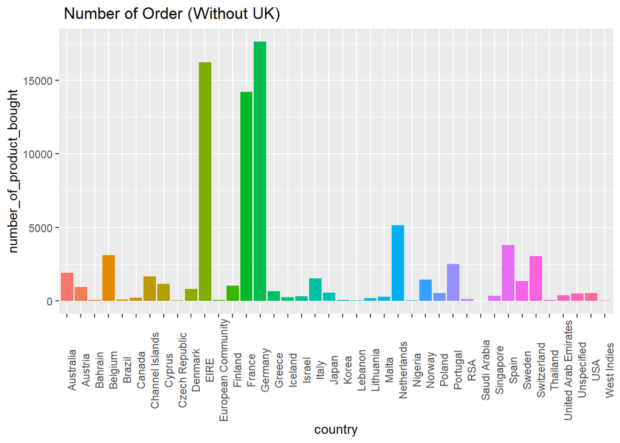

```r
#Number of Order without UK
Number_of_order_without_uk <- online_shop %>% filter(country != "United Kingdom") %>% group_by(country) %>% summarise(number_of_product_bought = n()) %>% arrange(desc(number_of_product_bought)) %>% ggplot(aes(x = country, y = number_of_product_bought, fill = country)) + geom_col(show.legend = FALSE) + theme(axis.text.x = element_text(angle = 90)) + labs(title = " Number of Order (Without UK)")
Number_of_order_without_uk
```

From the plot Number_of_order_without_uk it is visible that volume of order across country is varying too much.

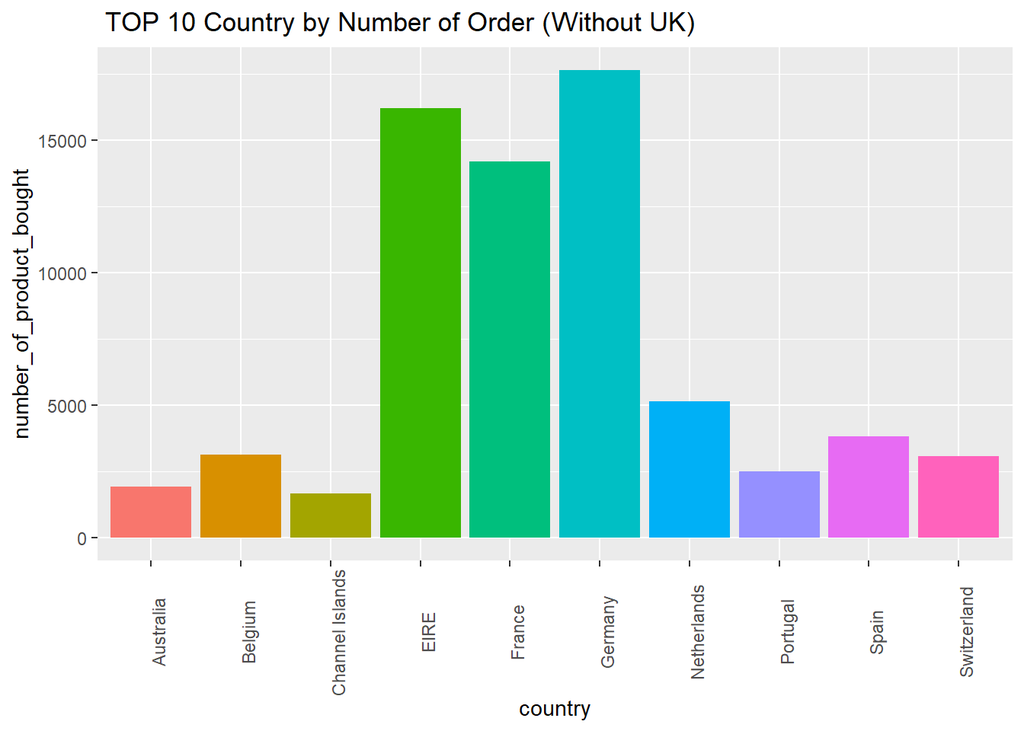

```r
#Ploting Top 10 country by Number of Order Without UK
Number_of_order_without_uk_top_10 <- online_shop %>% filter(country != "United Kingdom") %>% group_by(country) %>% summarise(number_of_product_bought = n()) %>% arrange(desc(number_of_product_bought)) %>% head(10) %>% ggplot(aes(x = country, y = number_of_product_bought, fill = country)) + geom_col(show.legend = FALSE) + theme(axis.text.x = element_text(angle = 90)) + labs(title = " TOP 10 Country by Number of Order (Without UK)")
Number_of_order_without_uk_top_10 #Viewing plot
```

From the plot Number_of_order_without_uk_top_10 Order volume is still varying among Top 10 country by order volume and most of the country has order number below 5000.

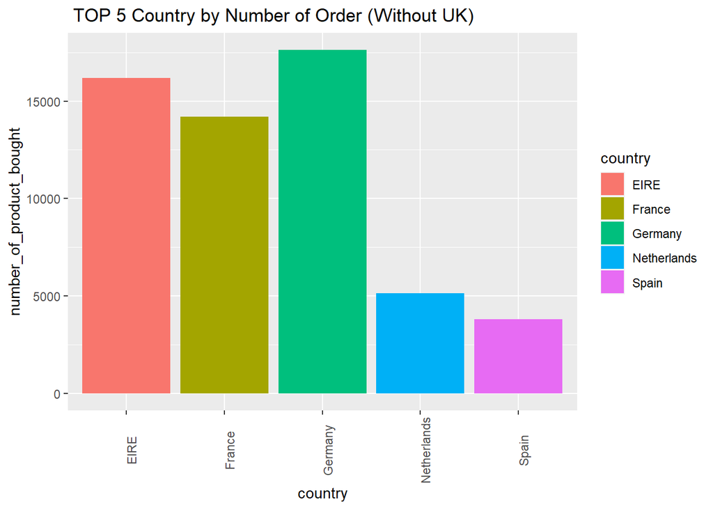

```r
#Ploting Top 5 country by Number of Order Without UK
Number_of_order_without_uk_top_5 <- online_shop %>% filter(country != "United Kingdom") %>% group_by(country) %>% summarise(number_of_product_bought = n()) %>% arrange(desc(number_of_product_bought)) %>% head(5) %>% ggplot() + geom_col(aes(x = country, y = number_of_product_bought, fill = country))+ theme(axis.text.x = element_text(angle = 90)) + labs(title = " TOP 5 Country by Number of Order (Without UK)")
Number_of_order_without_uk_top_5
```

As UK has most order, so considering Top 4 From Top 5 country by order for rest of analysis. while considering it is highly probable that next order will be placed from these Country First.

### Top products By Number Of Order

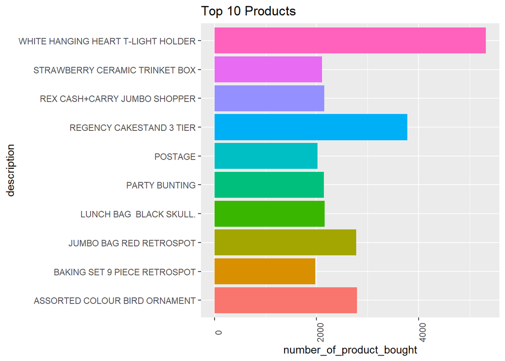

```r
#Ploting Top 10 products
Top_10_products <- online_shop %>% group_by(description) %>%  summarise(number_of_product_bought = n()) %>% arrange(desc(number_of_product_bought)) %>% head(10) %>% ggplot(aes(x = number_of_product_bought, y = description, fill = description)) + geom_col(show.legend = FALSE) + theme(axis.text.x = element_text(angle = 90)) + labs(title = "Top 10 Products ")
Top_10_products
```

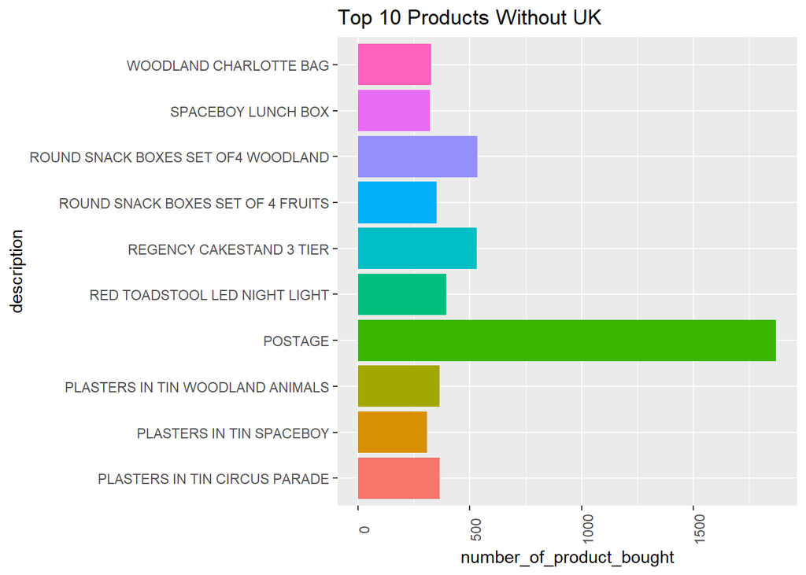

```r
#Ploting Top 10 products Without UK
Top_10_products_without_uk <- online_shop %>% filter(country != "United Kingdom") %>% group_by(description) %>%  summarise(number_of_product_bought = n()) %>% arrange(desc(number_of_product_bought)) %>% head(10) %>% ggplot(aes(x = number_of_product_bought, y = description, fill = description)) + geom_col(show.legend = FALSE) + theme(axis.text.x = element_text(angle = 90)) +  labs(title = "Top 10 Products Without UK ")
Top_10_products_without_uk
```

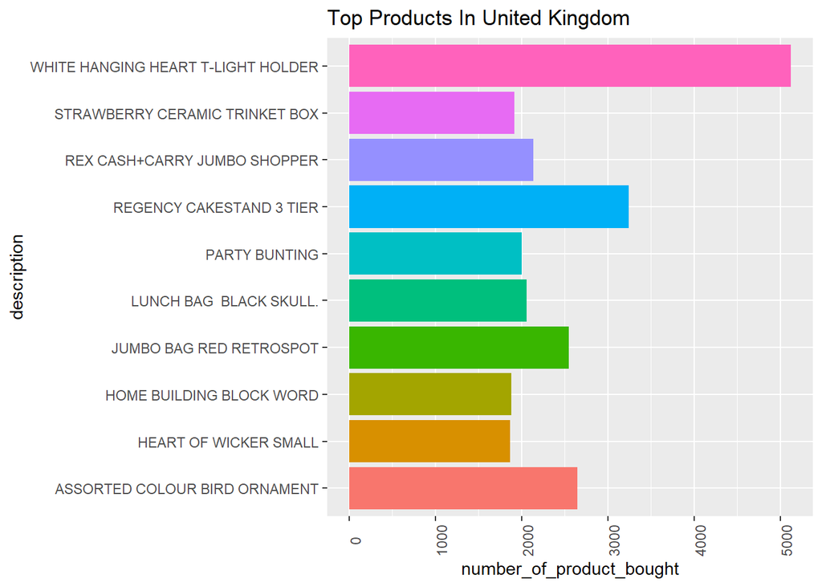

```r
#Ploting Top Products in Uk
Top_products_uk <- online_shop %>% filter(country == "United Kingdom") %>% group_by(description) %>%  summarise(number_of_product_bought = n()) %>% arrange(desc(number_of_product_bought)) %>% head(10) %>% ggplot(aes(x = number_of_product_bought, y = description, fill = description)) + geom_col(show.legend = FALSE) + theme(axis.text.x = element_text(angle = 90)) + labs(title = "Top Products In United Kingdom ")
Top_products_uk
```

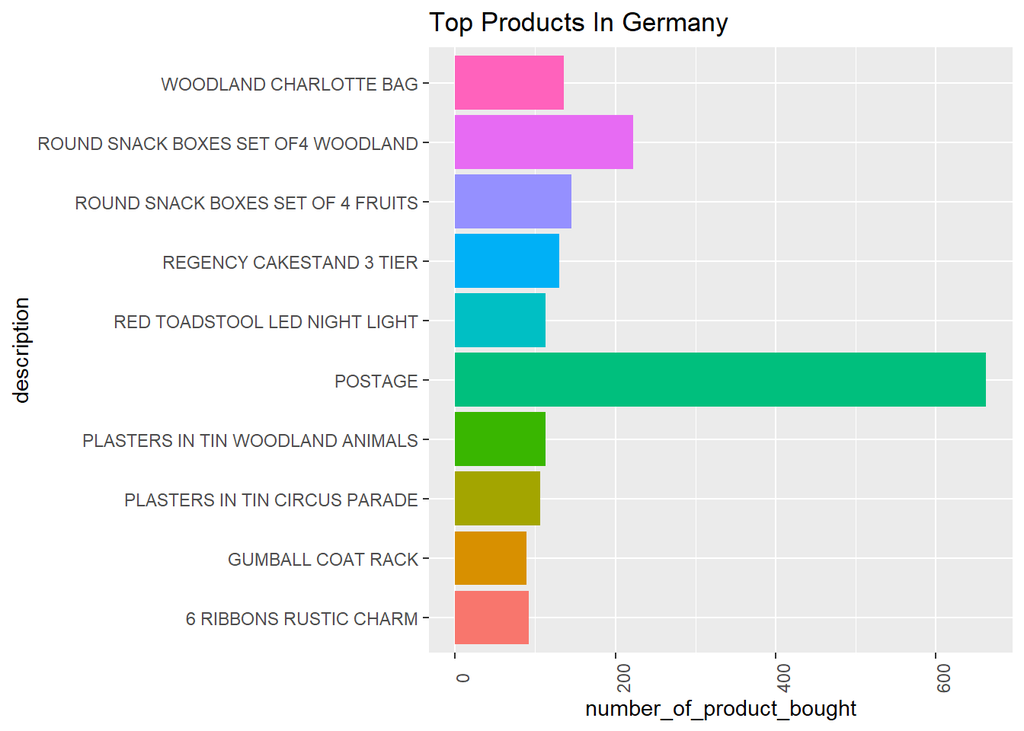

```r
#Ploting Top Products in Germany
Top_products_germany <- online_shop %>% filter(country == "Germany") %>% group_by(description) %>%  summarise(number_of_product_bought = n()) %>% arrange(desc(number_of_product_bought)) %>% head(10) %>% ggplot(aes(x = number_of_product_bought, y = description, fill = description)) + geom_col(show.legend = FALSE)  + theme(axis.text.x = element_text(angle = 90)) + labs(title = "Top Products In Germany ")
Top_products_germany
```

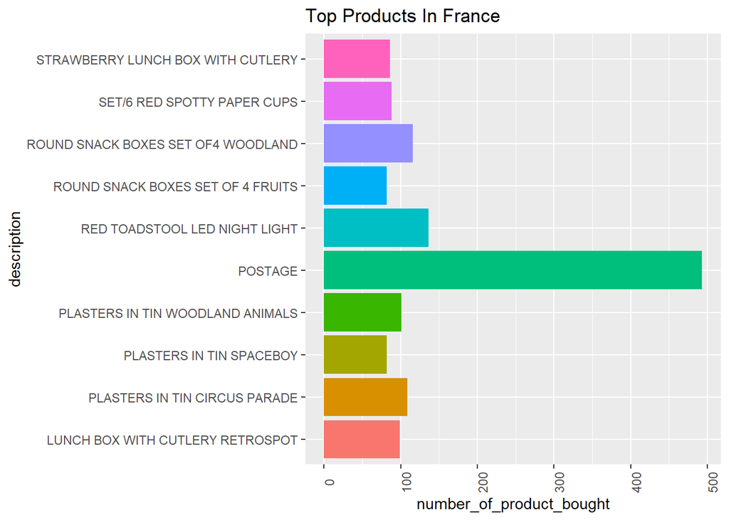

```r
#Ploting Top Products in France
Top_products_france <- online_shop %>% filter(country == "France") %>% group_by(description) %>%  summarise(number_of_product_bought = n()) %>% arrange(desc(number_of_product_bought)) %>% head(10) %>% ggplot(aes(x = number_of_product_bought, y = description, fill = description)) + geom_col(show.legend = FALSE) + theme(axis.text.x = element_text(angle = 90)) + labs(title = "Top Products In France ")
Top_products_france
```

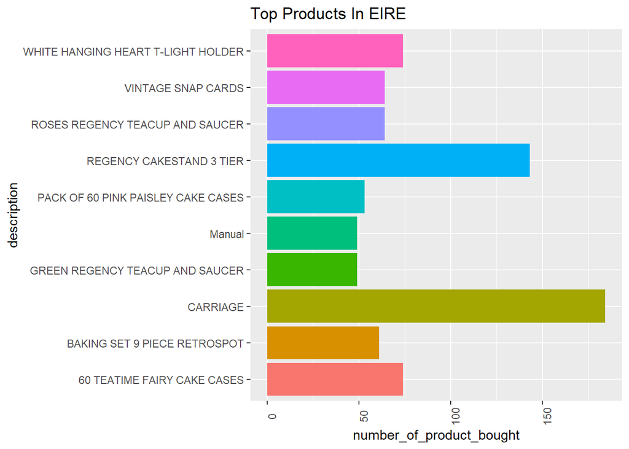

```r
#Ploting Top Products in EIRE
Top_products_eire <- online_shop %>% filter(country == "EIRE") %>% group_by(description) %>%  summarise(number_of_product_bought = n()) %>% arrange(desc(number_of_product_bought)) %>% head(10) %>% ggplot(aes(x = number_of_product_bought, y = description, fill = description)) + geom_col(show.legend = FALSE) + theme(axis.text.x = element_text(angle = 90)) + labs(title = "Top Products In EIRE ")
Top_products_eire
```

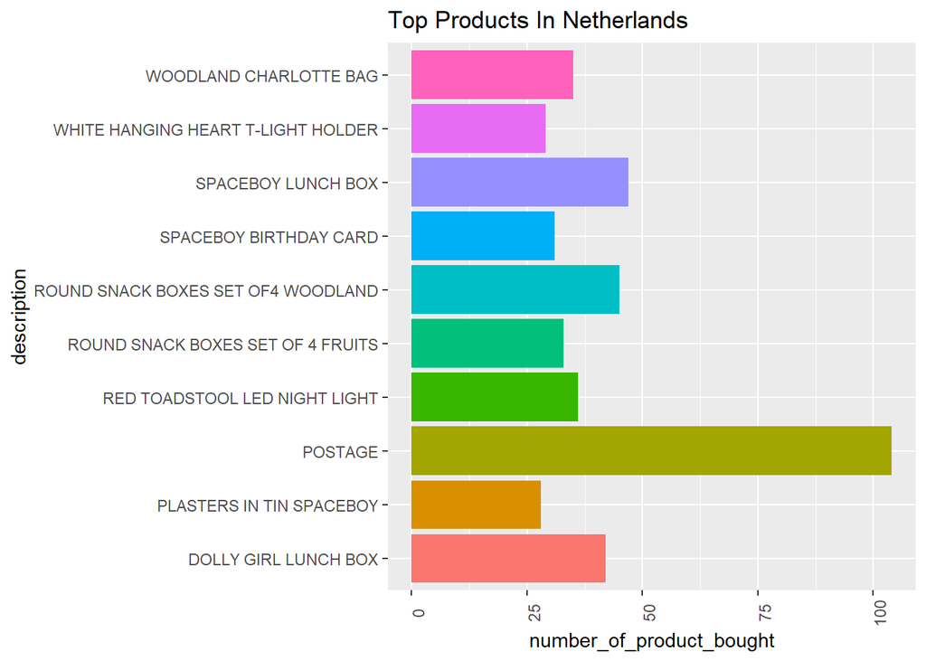

```r
#Ploting Top Products in Netherlands
Top_products_netherlands <- online_shop %>% filter(country == "Netherlands") %>% group_by(description) %>%  summarise(number_of_product_bought = n()) %>% arrange(desc(number_of_product_bought)) %>% head(10) %>% ggplot(aes(x = number_of_product_bought, y = description, fill = description)) + geom_col(show.legend = FALSE) + theme(axis.text.x = element_text(angle = 90)) + labs(title = "Top Products In Netherlands ")
Top_products_netherlands
```

### BESTSELLING Products By Total Sales

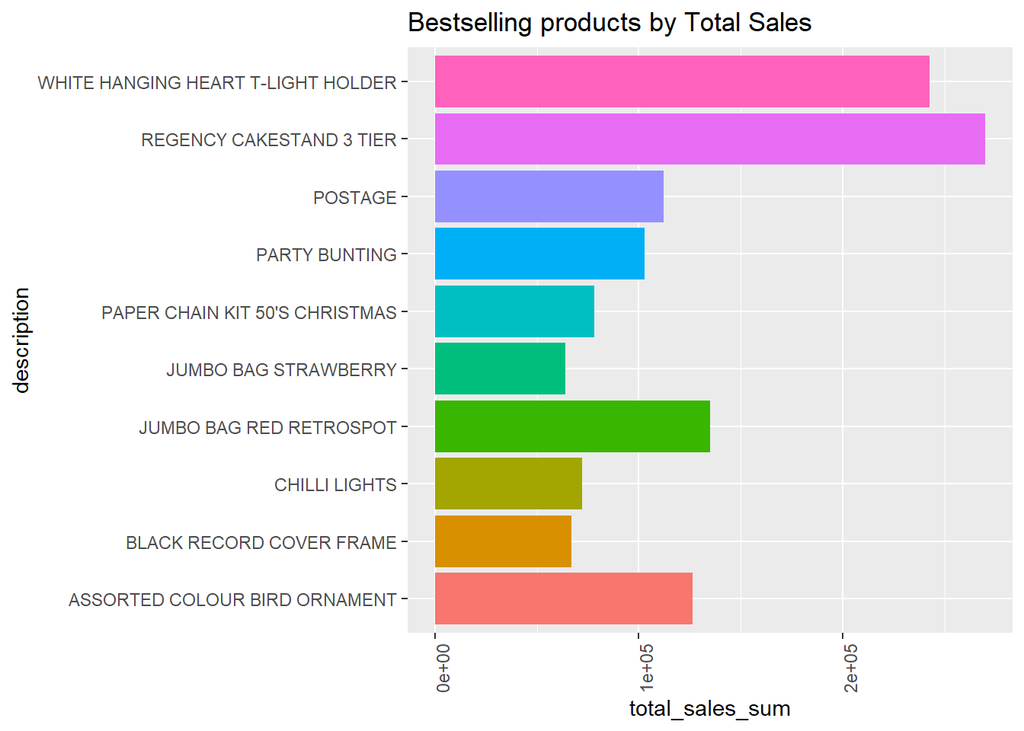

```r
#Ploting Top Products By Revenue
Bestselling_products <- online_shop %>% group_by(description) %>% summarise(total_sales_sum = sum(total_sales)) %>% arrange(desc(total_sales_sum)) %>% head(10) %>% ggplot(aes(x = total_sales_sum, y = description, fill = description)) + geom_col(show.legend = FALSE) + theme(axis.text.x = element_text(angle = 90)) + labs(title = "Bestselling products by Total Sales")
Bestselling_products
```

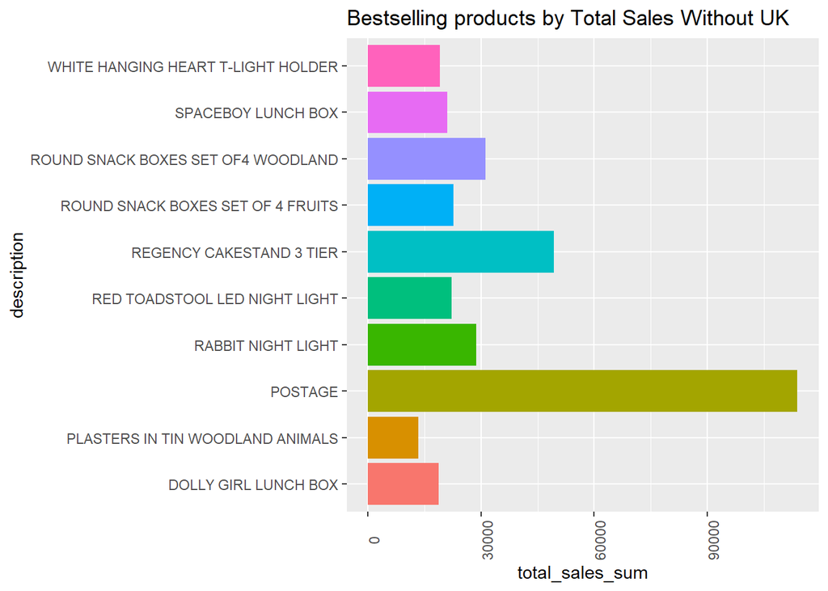

```r
#Ploting Top Products By Revenue Without UK
Bestselling_products_without_uk <- online_shop %>% filter(country != "United Kingdom") %>% group_by(description) %>% summarise(total_sales_sum = sum(total_sales)) %>% arrange(desc(total_sales_sum)) %>% head(10) %>% ggplot(aes(x = total_sales_sum, y = description, fill = description)) + geom_col(show.legend = FALSE)  + theme(axis.text.x = element_text(angle = 90)) + labs(title = "Bestselling products by Total Sales Without UK")
Bestselling_products_without_uk
```

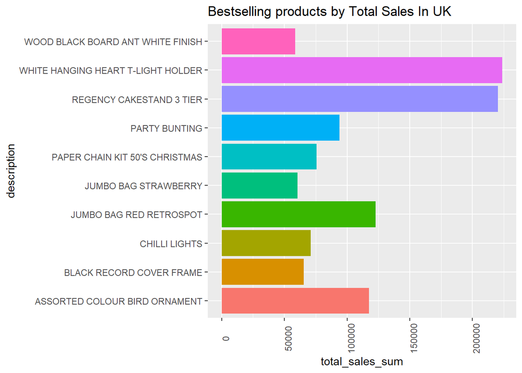

```r
#Ploting Top Products By Revenue In UK
Bestselling_products_uk <- online_shop %>% filter(country == "United Kingdom") %>% group_by(description) %>% summarise(total_sales_sum = sum(total_sales)) %>% arrange(desc(total_sales_sum)) %>% head(10) %>% ggplot(aes(x = total_sales_sum, y = description, fill = description)) + geom_col(show.legend = FALSE)  + theme(axis.text.x = element_text(angle = 90))  + labs(title = "Bestselling products by Total Sales In UK")
Bestselling_products_uk
```

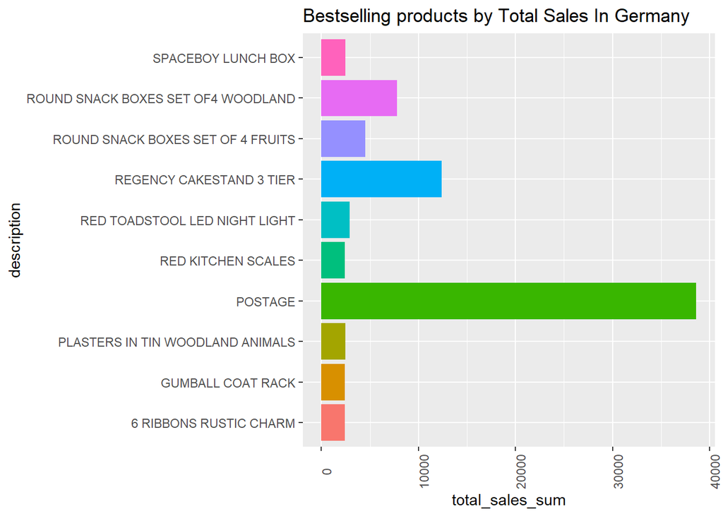

```r
#Ploting Top Products By Revenue In Germany
Bestselling_products_germany <- online_shop %>% filter(country == "Germany") %>%  group_by(description) %>% summarise(total_sales_sum = sum(total_sales)) %>% arrange(desc(total_sales_sum)) %>% head(10) %>% ggplot(aes(x = total_sales_sum, y = description, fill = description)) + geom_col(show.legend = FALSE) + theme(axis.text.x = element_text(angle = 90)) + labs(title = "Bestselling products by Total Sales In Germany")
Bestselling_products_germany
```

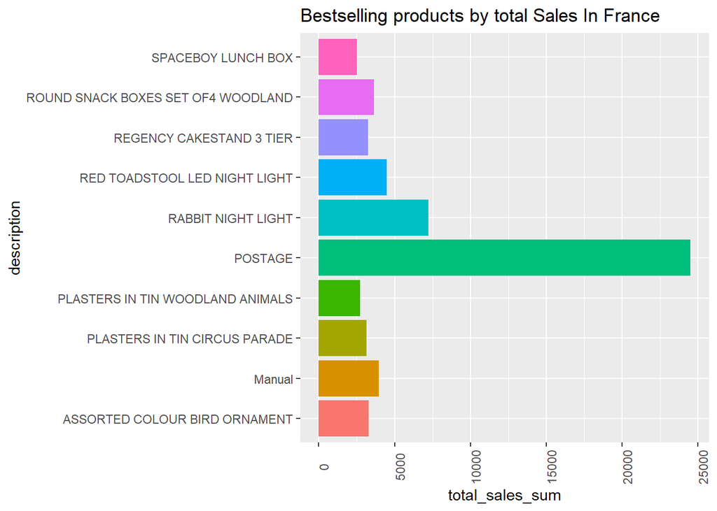

```r
#Ploting Top Products By Revenue In France
Bestselling_products_france <- online_shop %>% filter(country == "France") %>%  group_by(description) %>% summarise(total_sales_sum = sum(total_sales)) %>% arrange(desc(total_sales_sum)) %>% head(10) %>% ggplot(aes(x = total_sales_sum, y = description, fill = description)) + geom_col(show.legend = FALSE) + theme(axis.text.x = element_text(angle = 90)) + labs(title = "Bestselling products by total Sales In France")
Bestselling_products_france
```

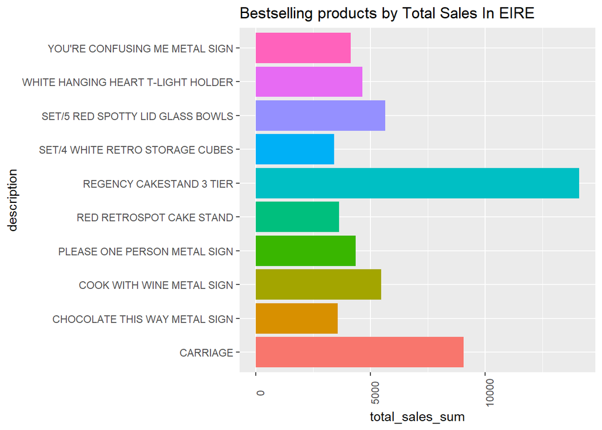

```r
#Ploting Top Products By Revenue In EIRE
Bestselling_products_eire <- online_shop %>% filter(country == "EIRE") %>%  group_by(description) %>% summarise(total_sales_sum = sum(total_sales)) %>% arrange(desc(total_sales_sum)) %>% head(10) %>% ggplot(aes(x = total_sales_sum, y = description, fill = description)) + geom_col(show.legend = FALSE) + theme(axis.text.x = element_text(angle = 90)) + labs(title = "Bestselling products by Total Sales In EIRE")
Bestselling_products_eire
```

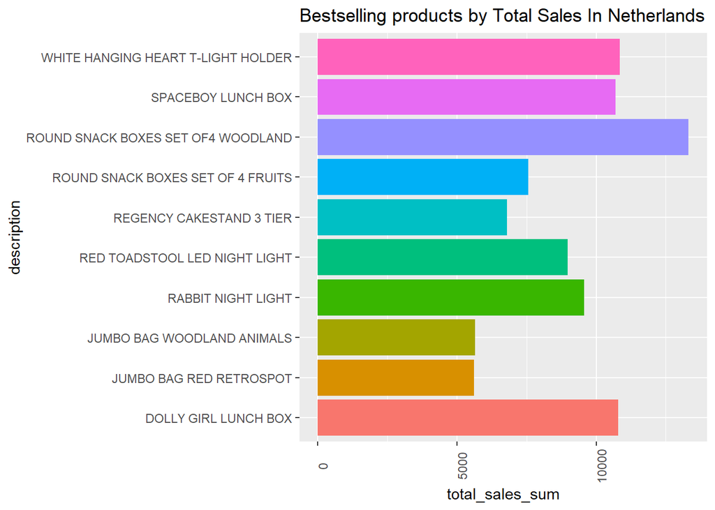

```r
#Ploting Top Products By Revenue In Netherlands
Bestselling_products_netherlands <- online_shop %>% filter(country == "Netherlands") %>%  group_by(description) %>% summarise(total_sales_sum = sum(total_sales)) %>% arrange(desc(total_sales_sum)) %>% head(10) %>% ggplot(aes(x = total_sales_sum, y = description, fill = description)) + geom_col(show.legend = FALSE) + theme(axis.text.x = element_text(angle = 90)) + labs(title = "Bestselling products by Total Sales In Netherlands")
Bestselling_products_netherlands
```

### Products Sold By Time

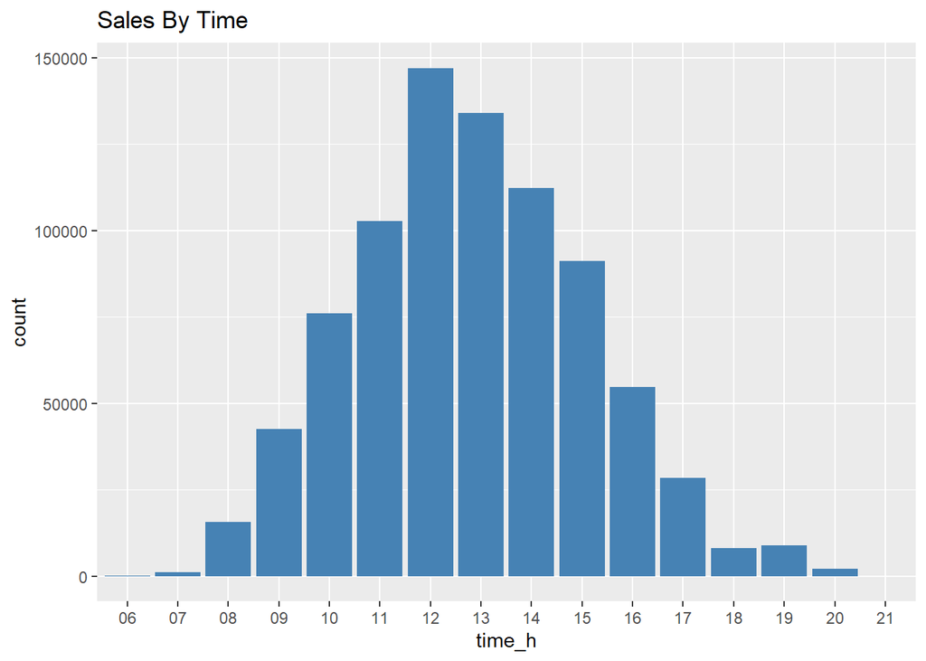

```r
#Sales By Time
Sales_by_time <- ggplot(data = online_shop, aes(x=time_h)) + geom_histogram(stat = "count", fill = "steelblue") +labs(title = "Sales By Time")
Sales_by_time
```

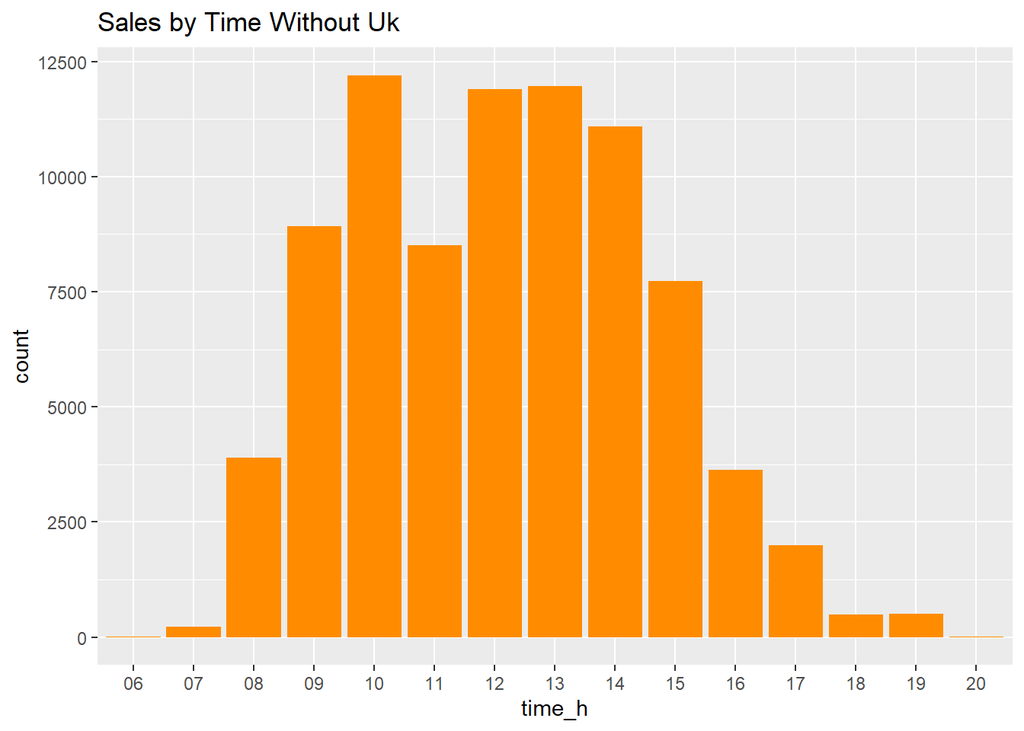

```r
#Sales By Time Without UK
Sales_by_time_without_uk <- online_shop %>% filter(country != "United Kingdom")%>% ggplot(aes(x = time_h))+ geom_histogram(stat = "count", fill = "darkorange") + labs(title = "Sales by Time Without Uk")
Sales_by_time_without_uk
```

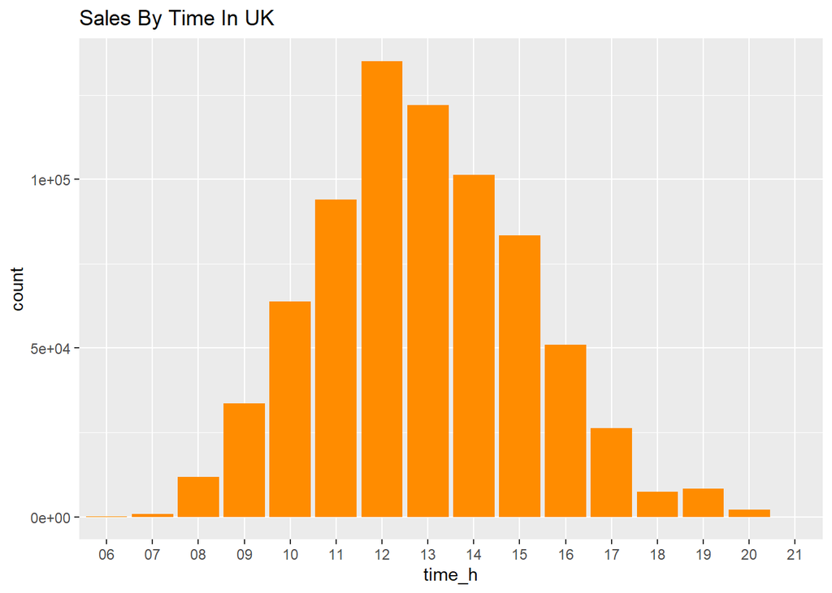

```r
#Sales By Time In UK
Sales_by_time_uk <- online_shop %>% filter(country == "United Kingdom")%>% ggplot(aes(x = time_h))+ geom_histogram(stat = "count", fill = "darkorange") +labs(title = "Sales By Time In UK")
Sales_by_time_uk
```

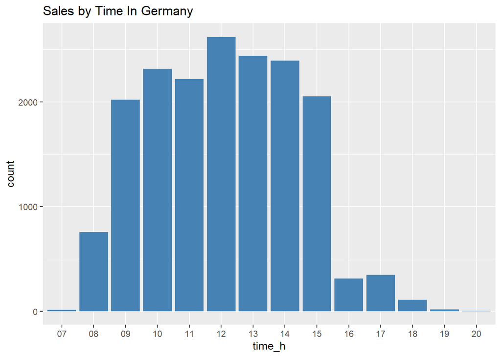

```r
#Sales By Time In Germany
Sales_by_time_germany <- online_shop %>% filter(country == "Germany") %>% ggplot(aes(x = time_h))+ geom_histogram(stat = "count", fill = "steelblue") +labs(title = "Sales by Time In Germany")
Sales_by_time_germany
```

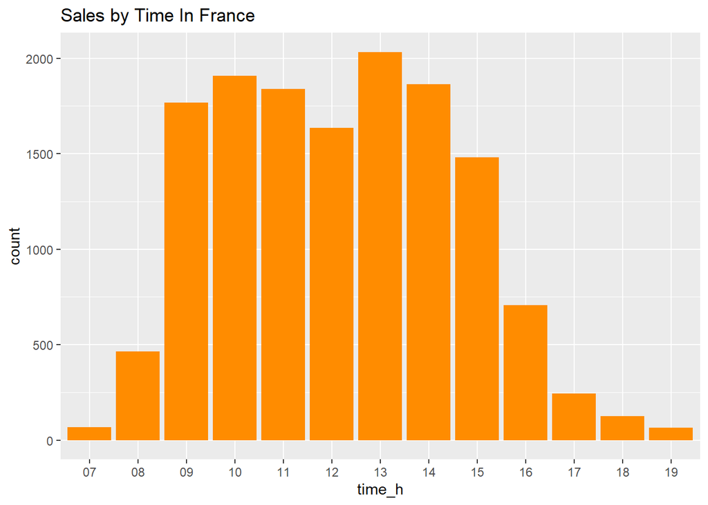

```r
#Sales By Time In France
Sales_by_time_france <- online_shop %>% filter(country == "France") %>% ggplot(aes(x = time_h))+ geom_histogram(stat = "count", fill = "darkorange") +labs(title = "Sales by Time In France")
Sales_by_time_france
```

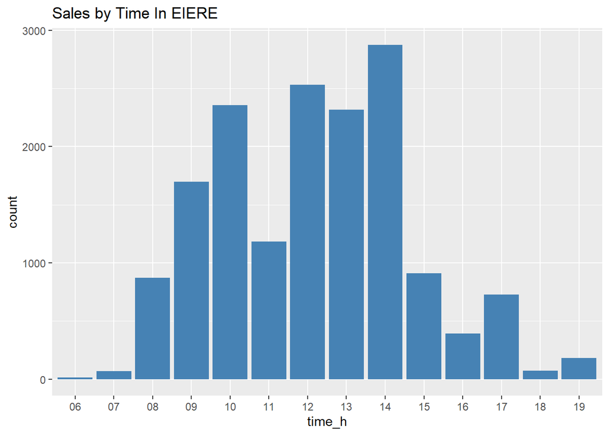

```r
#Sales By Time In EIRE
Sales_by_time_eire <- online_shop %>% filter(country == "EIRE") %>% ggplot(aes(x = time_h))+ geom_histogram(stat = "count", fill = "steelblue") +labs(title = "Sales by Time In EIERE")
Sales_by_time_eire
```

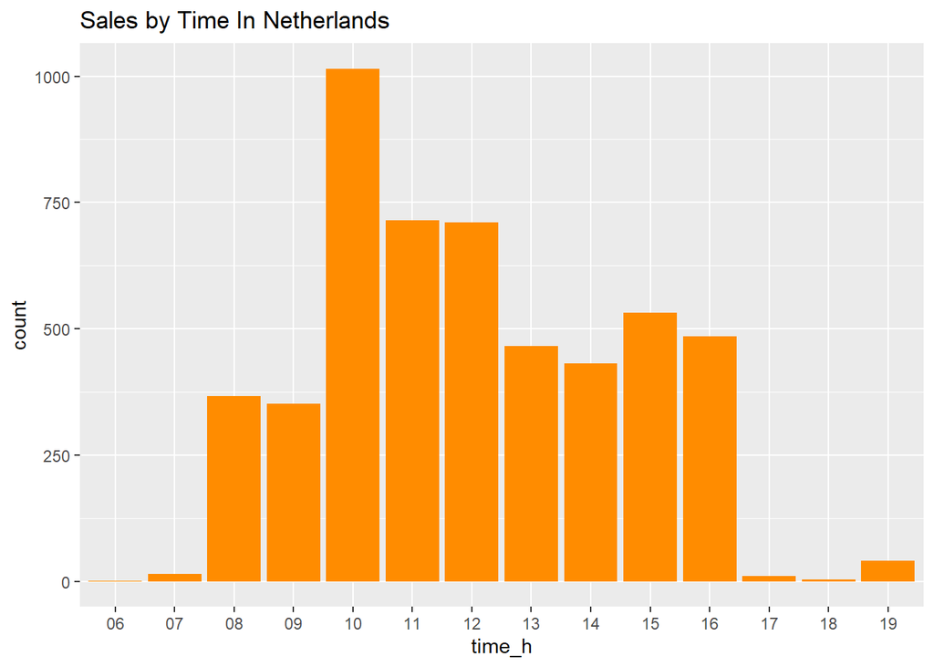

```r
#Sales By Time In Netherlands
Sales_by_time_netherlands <-online_shop %>% filter(country == "Netherlands") %>% ggplot(aes(x = time_h))+ geom_histogram(stat = "count", fill = "darkorange") +labs(title = "Sales by Time In Netherlands")
Sales_by_time_netherlands
```

### Total Sales By Month

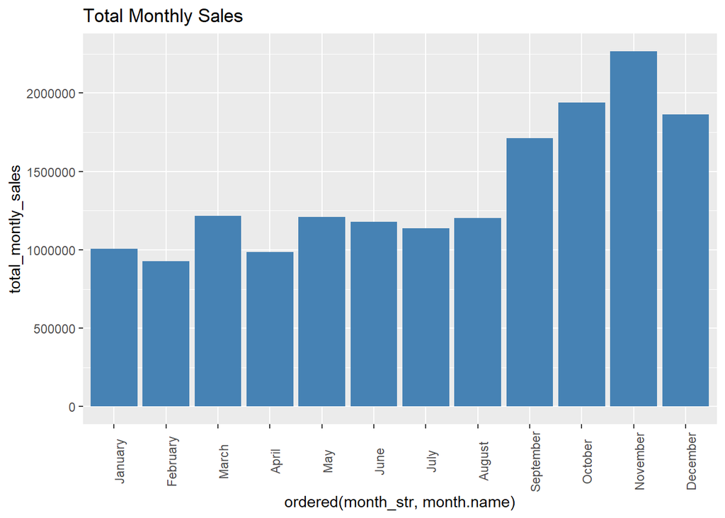

```r
#Total Monthly Sales
Monthly_sales <- online_shop %>% group_by(month_str) %>% summarise(total_montly_sales = sum(total_sales)) %>% ggplot(aes(x = ordered(month_str, month.name), y =total_montly_sales)) + geom_col( fill = "steelblue")+ theme(axis.text.x = element_text(angle = 90)) +labs(title = "Total Monthly Sales")
Monthly_sales
```

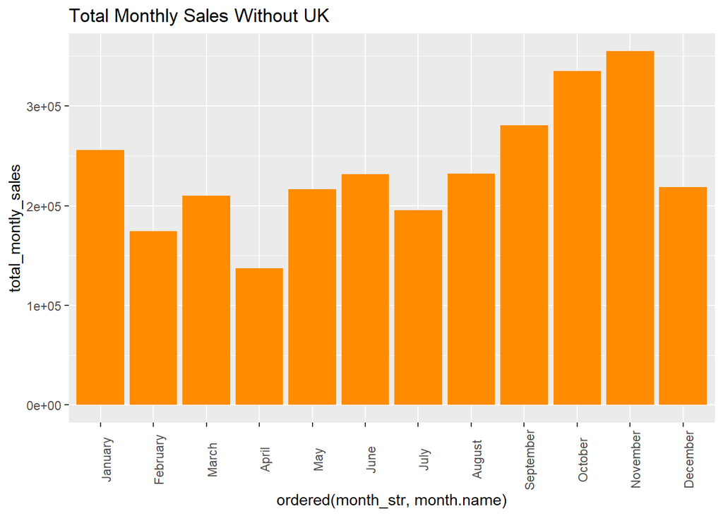

```r
#Total Monthly Sales Without UK
Monthly_sales_without_uk <-online_shop %>% filter(country != "United Kingdom")%>% group_by(month_str) %>% summarise(total_montly_sales = sum(total_sales)) %>% ggplot(aes(x = ordered(month_str, month.name), y =total_montly_sales)) + geom_col( fill = "darkorange")+ theme(axis.text.x = element_text(angle = 90)) +labs(title = "Total Monthly Sales Without UK ")
Monthly_sales_without_uk
```

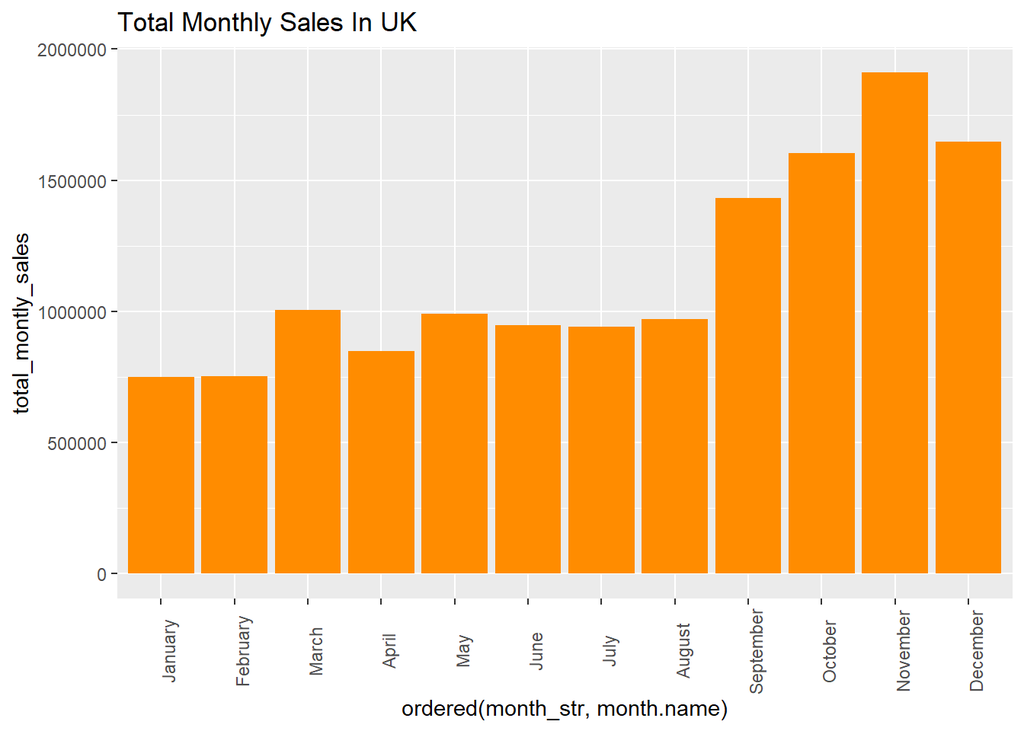

```r
#Monthly Sales In UK
Monthly_sales_in_uk <-online_shop %>% filter(country == "United Kingdom")%>% group_by(month_str) %>% summarise(total_montly_sales = sum(total_sales)) %>% ggplot(aes(x = ordered(month_str, month.name), y =total_montly_sales)) + geom_col( fill = "darkorange")+ theme(axis.text.x = element_text(angle = 90)) +labs(title = "Total Monthly Sales In UK")
Monthly_sales_in_uk
```

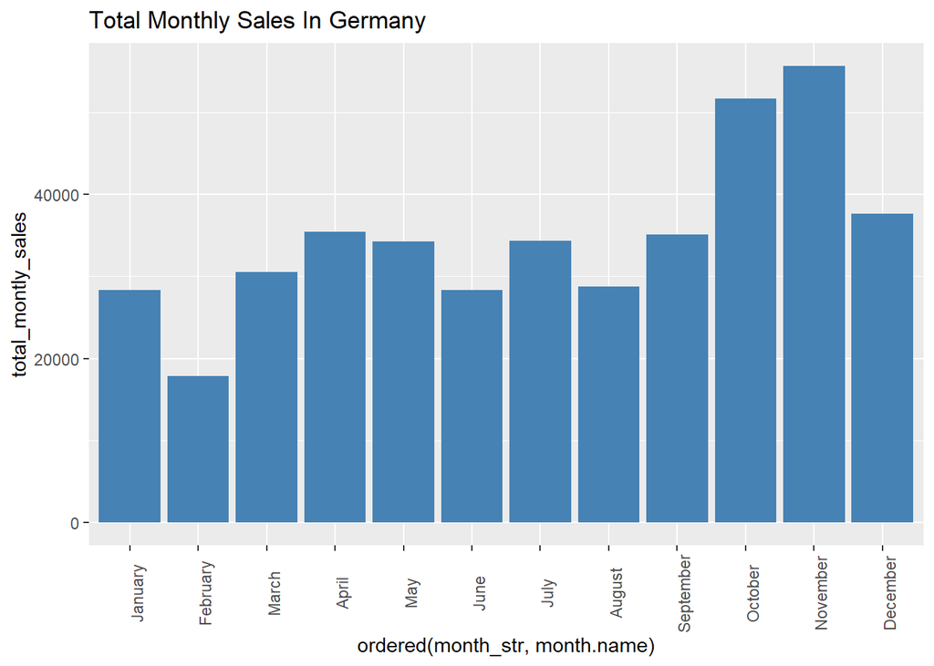

```r
#Total Monthly Sales In Germany
Monthly_sales_in_germany <-online_shop %>% filter(country == "Germany")%>% group_by(month_str) %>% summarise(total_montly_sales = sum(total_sales)) %>% ggplot(aes(x = ordered(month_str, month.name), y =total_montly_sales)) + geom_col( fill = "steelblue")+ theme(axis.text.x = element_text(angle = 90)) +labs(title = "Total Monthly Sales In Germany ")
Monthly_sales_in_germany
```

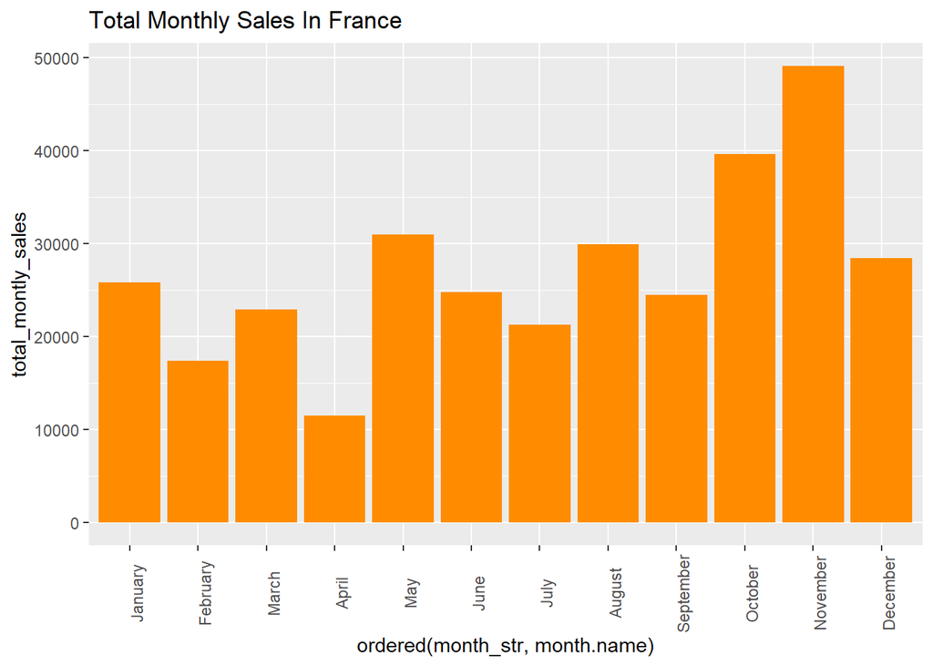

```r
#Total Monthly Sales In France
Monthly_sales_in_france <-online_shop %>% filter(country == "France") %>% group_by(month_str) %>% summarise(total_montly_sales = sum(total_sales)) %>% ggplot(aes(x = ordered(month_str, month.name), y =total_montly_sales)) + geom_col( fill = "darkorange")+ theme(axis.text.x = element_text(angle = 90)) +labs(title = "Total Monthly Sales In France ")
Monthly_sales_in_france
```

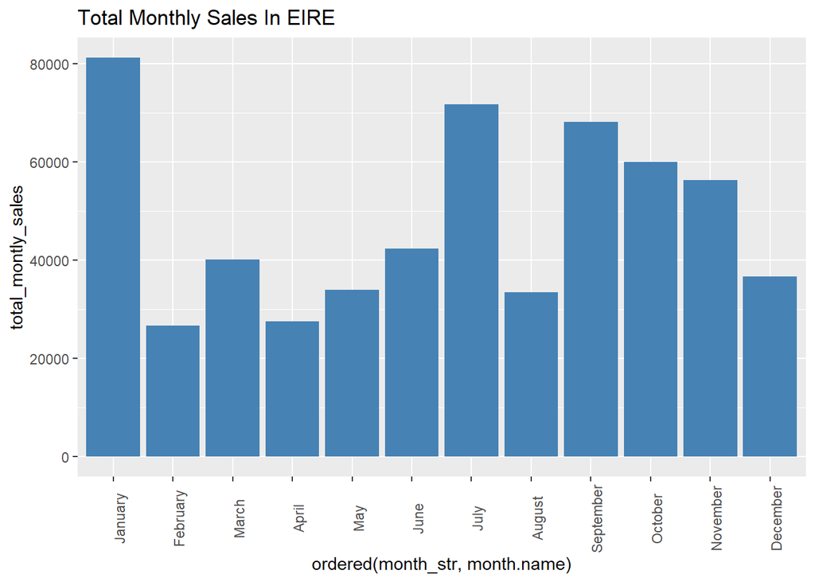

```r
#Total Monthly Sales In EIRE
Monthly_sales_in_eire <-online_shop %>% filter(country == "EIRE")%>% group_by(month_str) %>% summarise(total_montly_sales = sum(total_sales)) %>% ggplot(aes(x = ordered(month_str, month.name), y =total_montly_sales)) + geom_col( fill = "steelblue")+ theme(axis.text.x = element_text(angle = 90)) +labs(title = "Total Monthly Sales In EIRE")
Monthly_sales_in_eire
```

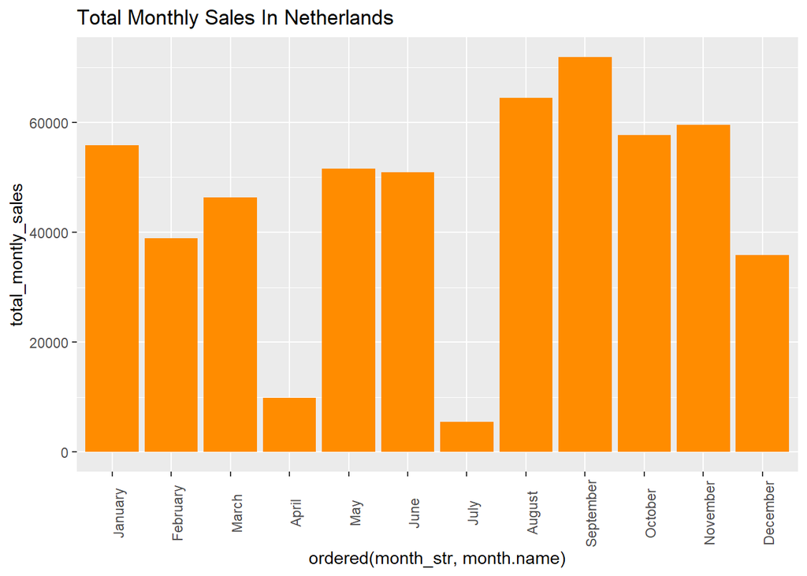

```r
#Total Monthly Sales In Netherlands
Monthly_sales_in_netherlands <-online_shop %>% filter(country == "Netherlands")%>% group_by(month_str) %>% summarise(total_montly_sales = sum(total_sales)) %>% ggplot(aes(x = ordered(month_str, month.name), y =total_montly_sales)) + geom_col( fill = "darkorange")+ theme(axis.text.x = element_text(angle = 90)) +labs(title = "Total Monthly Sales In Netherlands ")
Monthly_sales_in_netherlands
```